# What’s up Frank?

## Frank? Who the hell is Frank?

Frankie is a beloved household pet who’s serving as the focal point of this report.

## This! This is a “Frank”!

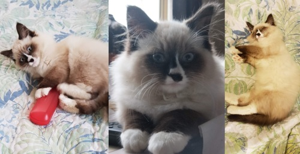

This is a Frank! (Frankie)

**Well… I mean… That’s a rather little Frankie…**

## Ahh, that’s more like it!

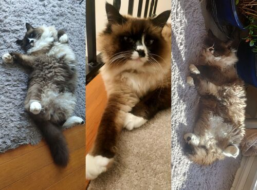

Ah, that’s more like it!

This is my cat, Frankie. We’re here to investigate how his behaviour changes based on a whole variety of variables!

Primarily, I’d like to investigate whether or not Frankie’s behaviour changes (such as, he yells at us more) depending on who we are, and how long we’re away for!

## Well, we’re busy people, but what does Frankie think?

Let’s first have a look at how long we’re away for and what time of the day we’re home for to record an observation!

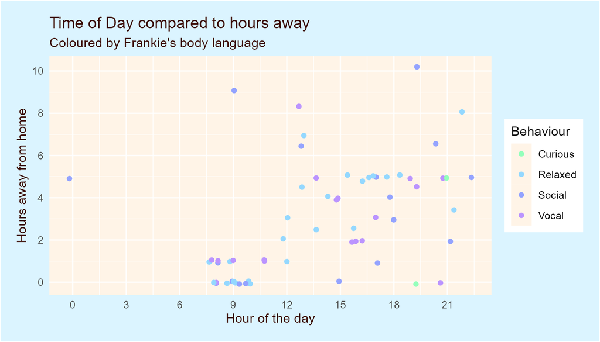

Scatter plot comparing the relationship between time of day and how long we’re away for

There’s not a whole lot going on here. Frankie seems to be the most relaxed during the morning when we haven’t left the house yet, and tends to become more active throughout the day. He seems to like to chat or hang around at any time of the day!

## Well… Who is “we”?

There are 3 total household members existing in Frankie’s kingdom (our house). Labelled, B, D and R. We had some family members come over for a special occassion and they were included in the observational data.

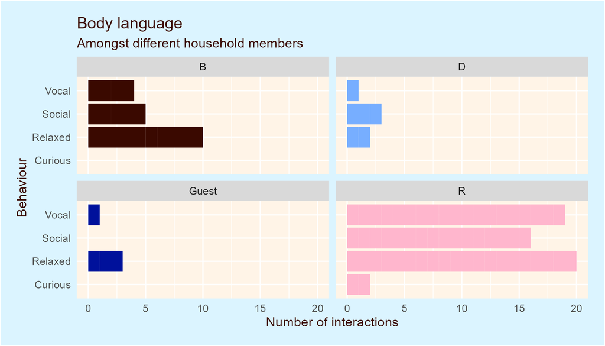

Bar graph comparing body language per different family member

Since social and vocal are our biggest bars excluding Frankie’s lazy behaviour, let’s have a look at that!

## A talkative fella! What for?

Well, Frankie clearly likes people quite a bit. But what’s the context behind that?

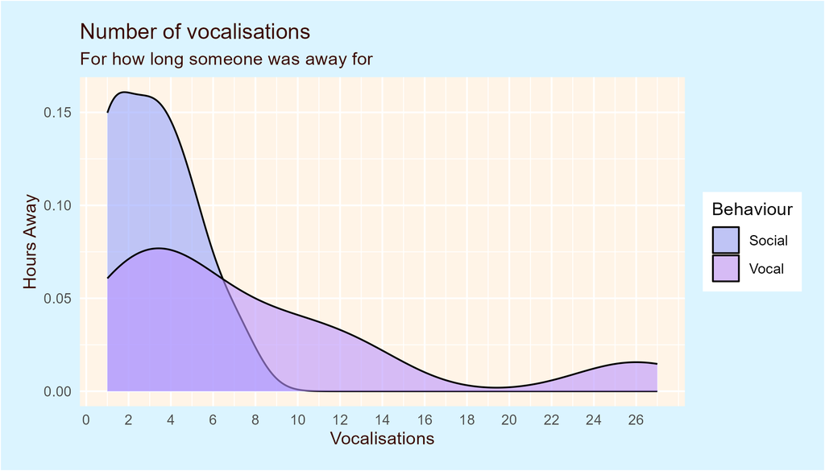

Density plot visualising the density of vocalisation counts separated by behaviours “Social” and “Vocal”

Here we can visualise how many times he meows, or, makes noise depending on whether the tonality of his vocalisation is to be social - or to just yell!

There’s a pretty clear distinction between how much he meows between a social behaviour and a vocal behaviour. When he’s feeling a bit more social, he generally meows less, up to 8 times and a density highest in the lower region(1-4 vocalisations). Whereas, when he’s feeling vocal he tends to meow a whole lot more, stretching the range out to a whopping 27 vocalisations. Although he doesn’t often make 16-27 vocalisations, the density suggests that he talks more when he’s feeling vocal overall.

There doesn’t seem to be a particular reason why he likes to chat, as it seems he likes to chat and yell a bit all around the clock, with anyone, no matter how long you’re gone for.

## Thanks for reading!

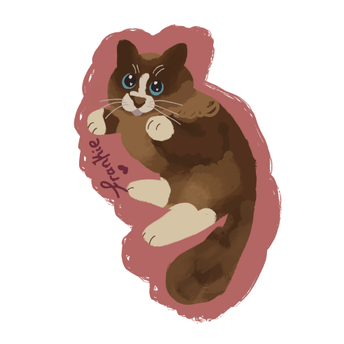

Art by Ben Luo

*Art by Ben Luo*